# Employee data simulation - IT

Maja B

2024-08-08

```r
data=read.csv('employee_data.csv') # code to read/obtain the data in the project
attach(data) #code so we don't have to write the dataset name all over again in the analysis
```

# Origin of the dataset

The dataset has been found and downloaded on Kaggle - https://www.kaggle.com/datasets/abhayayare/employee-data-simulation-it-industry. This raw data contains simulated data of 400 employees which ware working on various IT positions. According to the original poster of the dataset, the dataset was generated using Faker library in Python.

# Explanations of the variables and plan for analysis

This dataset consists of 5 different variables: 1) ID - an unique identifier for each employee (we can ignore it here) 2) gender - either M for Male or F for female 3) experience in years 4) position 5) salary - in USD

Plan for analysis consists of the following steps: a. create numerical summaries for each variables b. check distribution of each variable by graphically showing it with boxplot and histogram/barplot c. if there will be outliers, make a decision what are we going to do with them? d. proceed with outlier cleansing e. try to find relationships between the variables (we can do hypothesis testing, regression analysis, trending…)

# Summaries and graphical notations of the variables

```r
#checking for missing values, there are none.
which(is.na(data))
```

```
## integer(0)
```

```r
sum(is.na(data))
```

```
## [1] 0
```

We don’t have any missing values.

```r
#summaries of variables + checking IQR + checking what are the Q1/Q3 +/- 1,5*IQR borders, as I assume already that salaries will be a variable with outliers.
summary(data)
```

```
##        ID           Gender          Experience..Years.   Position
##  Min.   :  1.0   Length:400         Min.   : 0.00      Length:400
##  1st Qu.:100.8   Class :character   1st Qu.: 4.00      Class :character
##  Median :200.5   Mode  :character   Median :10.00      Mode  :character
##  Mean   :200.5                      Mean   : 9.67
##  3rd Qu.:300.2                      3rd Qu.:15.00
##  Max.   :400.0                      Max.   :20.00
##      Salary
##  Min.   : 43643
##  1st Qu.:100485
##  Median :128562
##  Mean   :131701
##  3rd Qu.:157735
##  Max.   :269950
```

```r
IQR_Exp=IQR(Experience..Years.)
IQR_Sal=IQR(Salary)
#lower_border= Q1 - 1,5 * IQR_Sal (for salaries)
lower_border= 100485 - 1.5 * IQR_Sal
#upper_border= Q3 + 1,5 * IQR_Sal (for salaries)
upper_border = 157735 + 1.5 * IQR_Sal
print(lower_border)
```

```
## [1] 14609.62
```

```r
print(upper_border)
```

```
## [1] 243610.4
```

Variables such as gender and position are categorical, so there is no mean or median value. If we want to show mode of the categorical values, we have to convert them into factors. For now, I will not do that.

While looking at the numerical variables, such as experience in years and salary, I can see that the median and mean values are quite close, but the range is quite large, so I will make graphics such as boxplot and histogram, to see if we have some outliers. When it comes to ID variable, I am not working with it in this case. In real world, salaries oftentimes don’t have the normal distribution, but my opinion is that IT salaries perhaps might have a normal distribution in real world (think about the ratio of juniors and seniors on each side, there is probably more people who keep themselves on the medior position).

Below you can see the code for histogram for numerical variables.

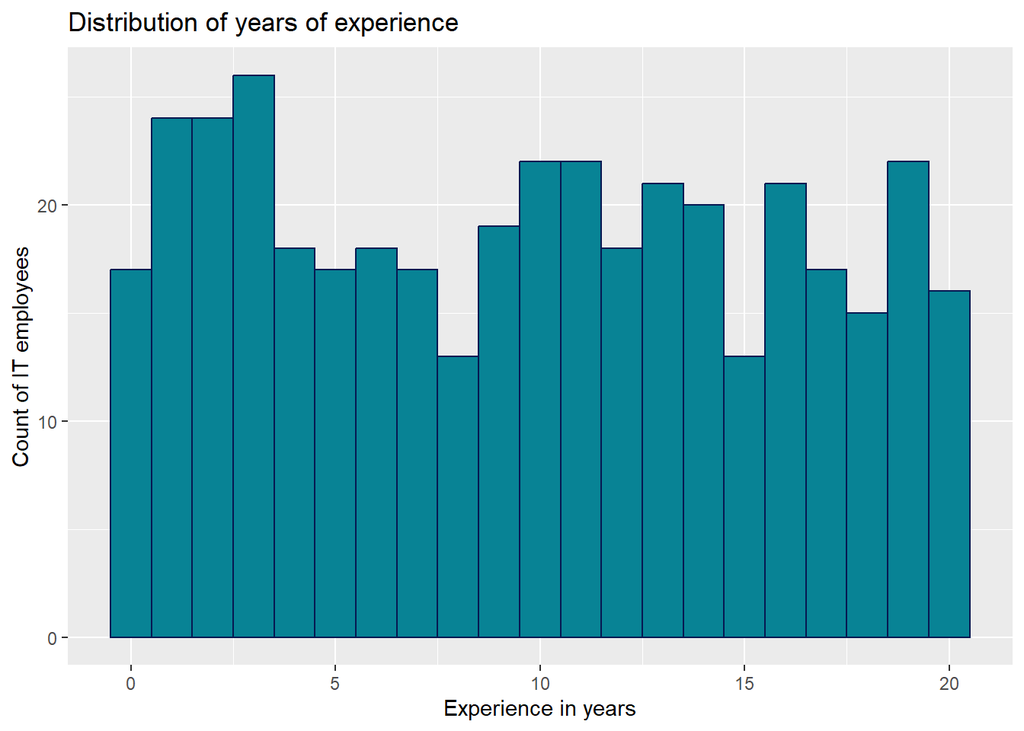

```r
library(ggplot2)
main = ggplot(data,aes(x=Experience..Years.)) #histogram for years of experience
main + geom_histogram(fill="#088395",colour="#071952",binwidth=1) + ggtitle("Distribution of years of experience") + xlab("Experience in years") + ylab("Count of IT employees")
```

Experience in years among IT employees is scattered from 0 to 20 years, with median and mean values being quite close together (around 10 years of experience).

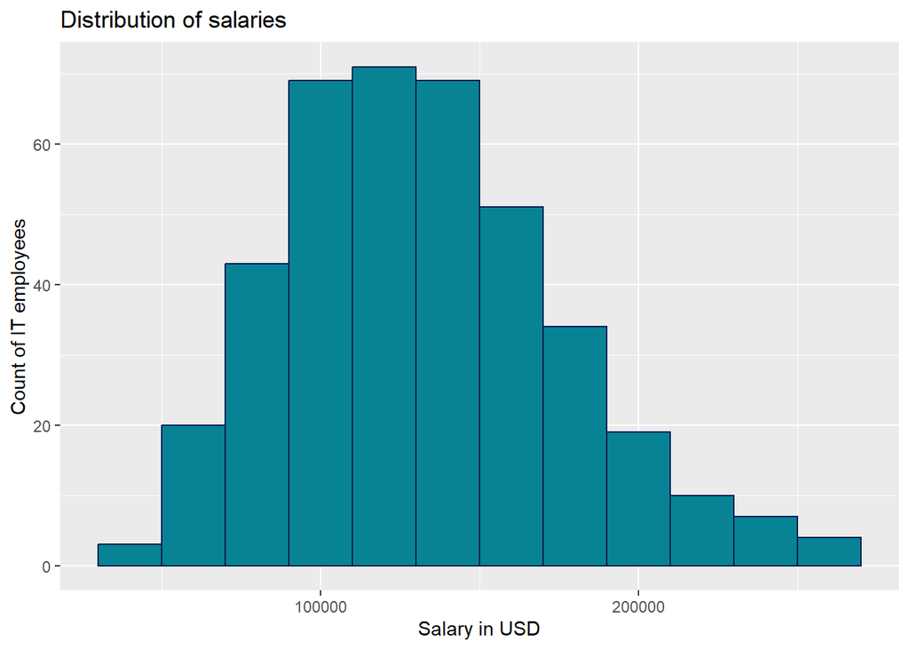

```r
options(scipen=999) #to mitigate e-numbers on our histograms
main = ggplot(data,aes(x=Salary)) #histogram for salaries
main + geom_histogram(fill="#088395",colour="#071952",binwidth=20000) + ggtitle("Distribution of salaries") + xlab("Salary in USD") + ylab("Count of IT employees")
```

Unlike the experience distribution, this distribution of salaries among IT employees does have gaussian type, normal look of distributions, although we see some tails on the higher(right) side of the distribution. We can say, from the summary, that the median and mean vaulues are closer together (128k vs 131k), but IQR is around 57,2k which is a higher range.

Let’s check boxplots to see if we can hunt down some outliers for these variables.

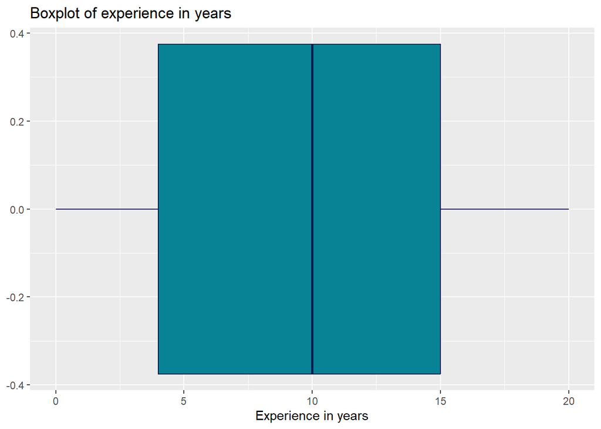

```r
ggplot(data,aes(x=Experience..Years.)) + geom_boxplot(fill="#088395",colour="#071952") + ggtitle("Boxplot of experience in years") + xlab("Experience in years")
```

Boxplot for experience in years doesn’t show any outliers, we will proceed with this variable as it is.

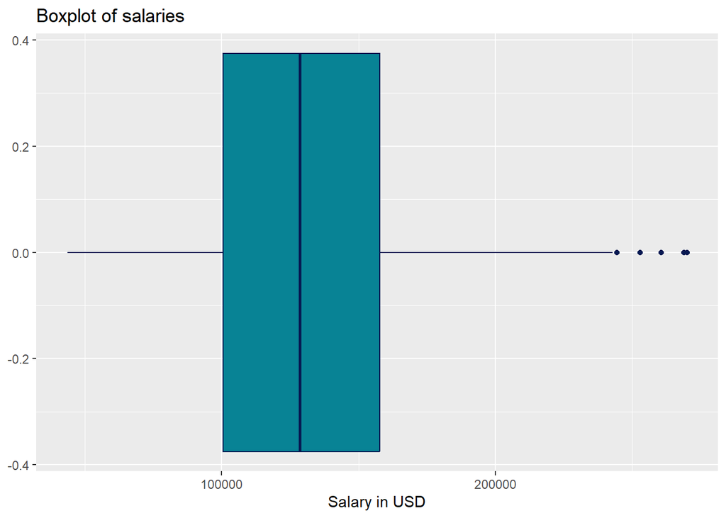

```r
ggplot(data,aes(x=Salary)) + geom_boxplot(fill="#088395",colour="#071952") + ggtitle("Boxplot of salaries") + xlab("Salary in USD")
```

As predicted, and seen on histogram, variable salary in USD has some outliers on the higher side. Let’s code more to see how many of them do we have and if it is possible to delete them, if they don’t make a big portion of the dataset.

```r
boxplot.stats(data$Salary)$out #code to see the values of the outliers shown on boxplot
```

```
## [1] 260594 269950 268774 244446 252949
```

```r
out=boxplot.stats(data$Salary)$out
out_ind=which(data$Salary %in% c(out)) #code to see in which rows are those outliers in the dataset
out_ind
```

```
## [1]  62 116 121 162 260
```

You can see that we have 5 outliers, which only makes 1,25% of the whole dataset. I will go further with deleting these outliers, so we can draw out some relationships between the categorical and numerical values, and so it doesn’t hinder our hypothesis testing and predictive analysis processes later on.

```r
# Remove rows where Salary is higher than the upper_border which we have calculated in the beginning
data <- data[data$Salary <= 243610.4, ]
# Print and attach the modified data frame
print(data)
```

[output not shown]

[output cut: 381 more lines]

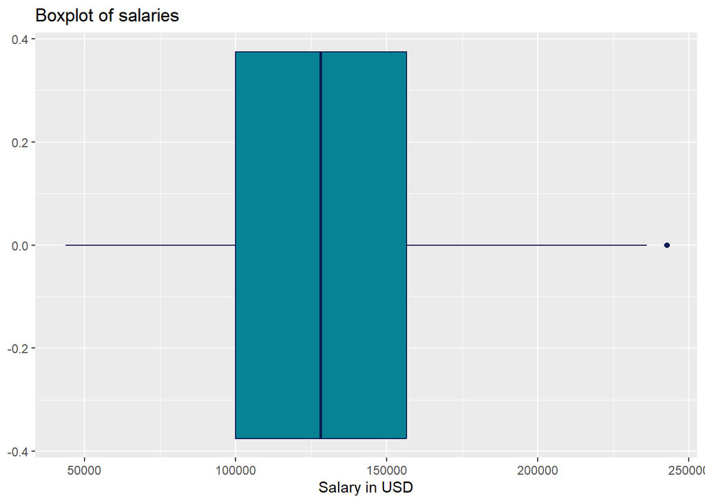

```r
ggplot(data,aes(x=Salary)) + geom_boxplot(fill="#088395",colour="#071952") + ggtitle("Boxplot of salaries") + xlab("Salary in USD")
```

Now, after deleting those 5 values, we still have one outlier, but that only then makes 0,25% of all values. I am deciding to keep it, as it probably won’t hinder our predictive processes later on.

# Relationships between categorical and numerical values

In order to discover relationships between these variables in the dataset, we have to ask ourselves some questions:

1. How does the distribution of experience in years look like between genders?
2. How does the distribution of salary in USD look like between genders?
3. Do employees with more experience earn more money?
4. What is the difference between salaries between positions?
5. If I have 5 years of experience, what will my salary be?

The first four questions are just based on/in this sample, while the 5th question is going to be checked via linear regression analysis, if all prerequisites for it are checked and correct.

## 1. How does the distribution of experience in years look like between genders?

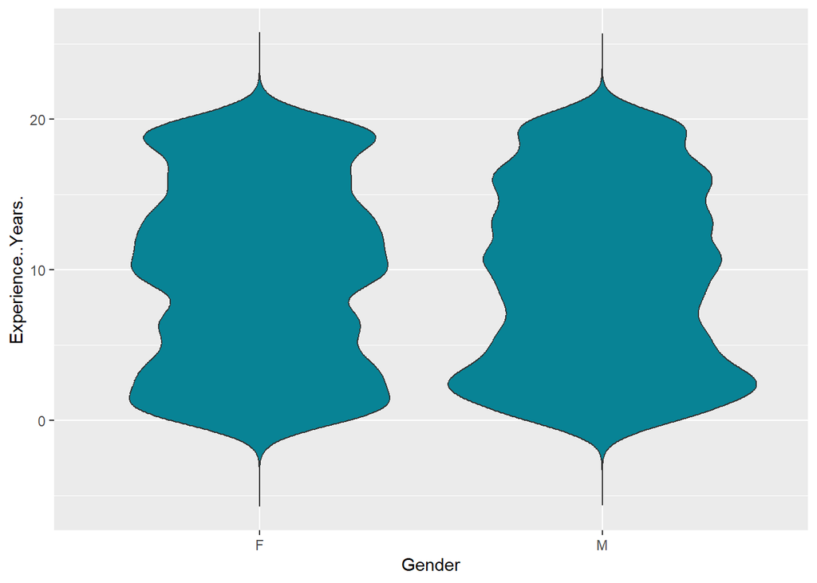

```r
basic = ggplot(data,aes(x=Gender,y=Experience..Years.))
basic + geom_violin(trim=FALSE,adjust=0.5,fill="#088395") #trim is false so we don't get flat top and bottom
```

This violin is another way how to present a boxplot. I thought this was a much nicer way to show how the years of experience go in between genders (think of the age pyramid). On this boxplot, we can see that more male IT employees have between 0-5 years of experience, while more female IT employees have between 8 and 15 years of experience.

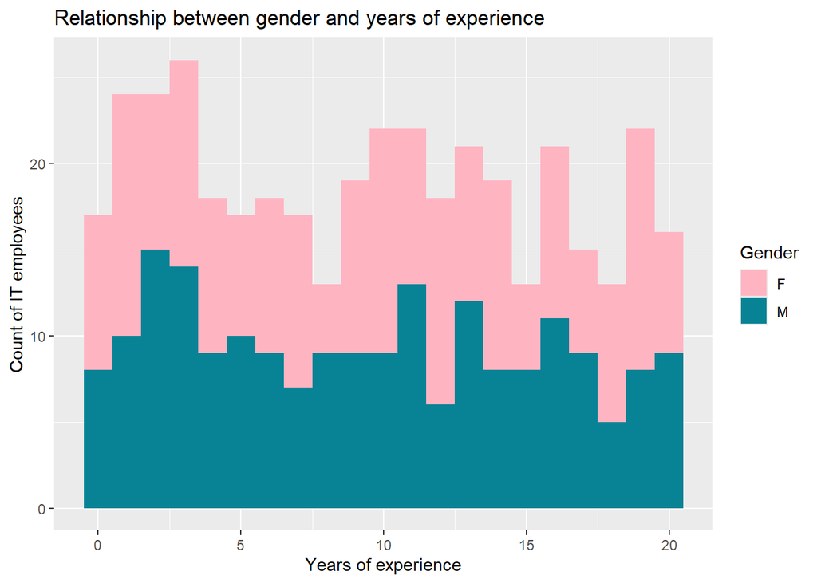

```r
library(ggplot2)
main = ggplot(data,aes(x=Experience..Years.,fill=Gender))
main + geom_histogram(binwidth=1) + ggtitle("Relationship between gender and years of experience") + xlab("Years of experience") + ylab("Count of IT employees") + scale_fill_manual(values=c("M"="#088395","F" = "#FFB4C2"))
```

This histogram also shows that in a more visible manner.

## 2. How does the distribution of salary in USD look like between genders?

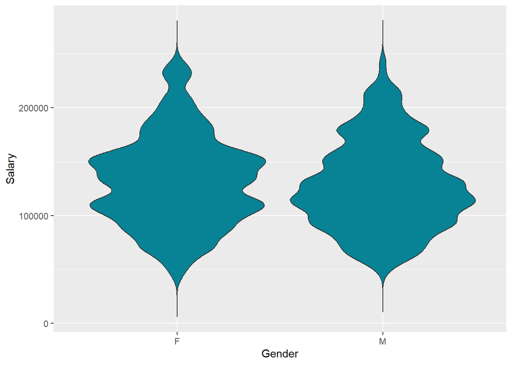

```r
basic = ggplot(data,aes(x=Gender,y=Salary))
basic + geom_violin(trim=FALSE,adjust=0.5,fill="#088395")
```

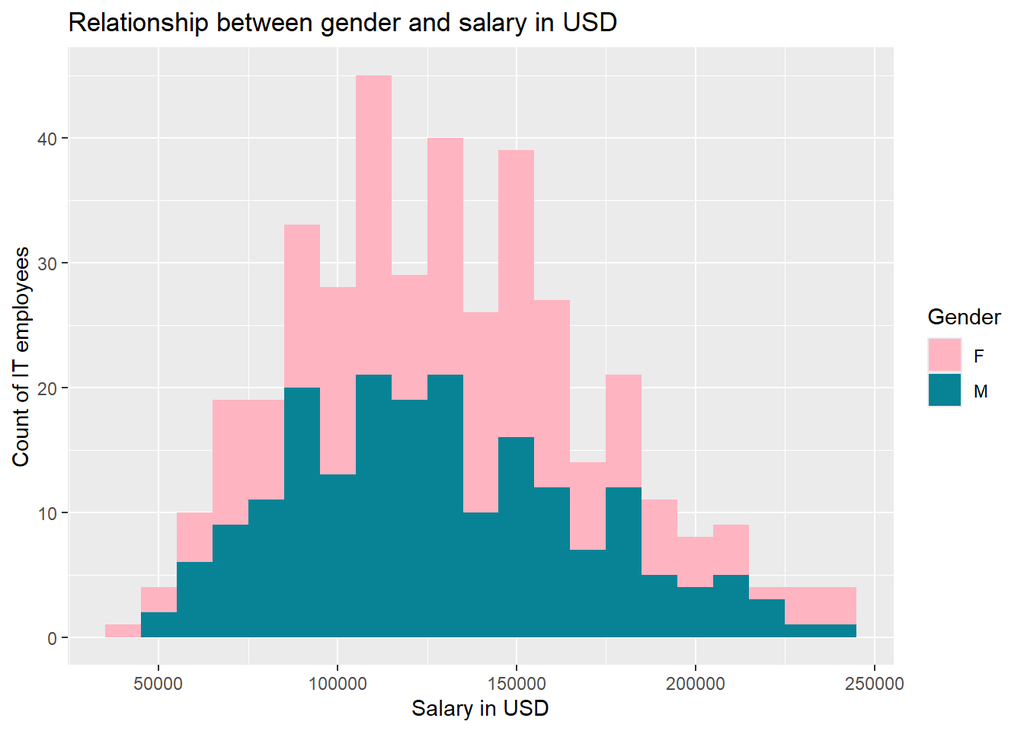

```r
main = ggplot(data,aes(x=Salary,fill=Gender))
main + geom_histogram(binwidth=10000) + ggtitle("Relationship between gender and salary in USD") + xlab("Salary in USD") + ylab("Count of IT employees") + scale_fill_manual(values=c("M"="#088395","F" = "#FFB4C2"))
```

## 3. Do employees with more experience earn more money?

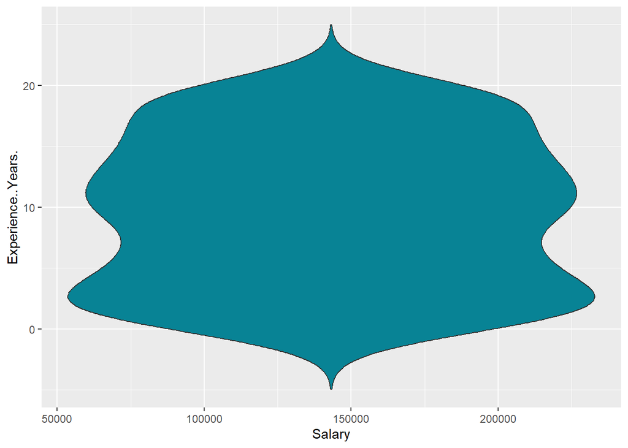

```r
basic = ggplot(data,aes(x=Salary,y=Experience..Years.))
basic + geom_violin(trim=FALSE,adjust=1,fill="#088395")
```

Let’s see what scatter plot shows.

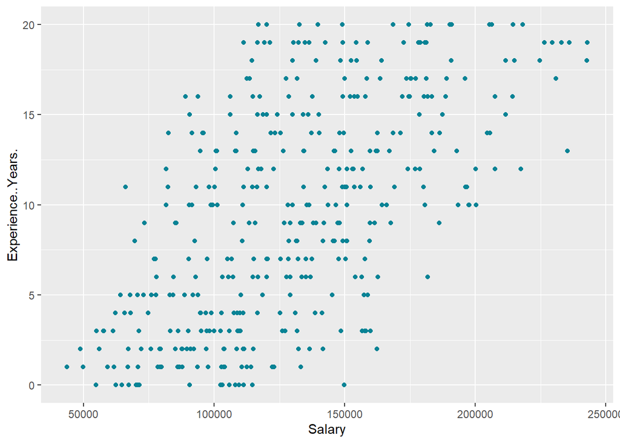

```r
ggplot(data,aes(x=Salary,y=Experience..Years.)) + geom_point(color="#088395")
```

## 4. What is the difference between salaries between positions?

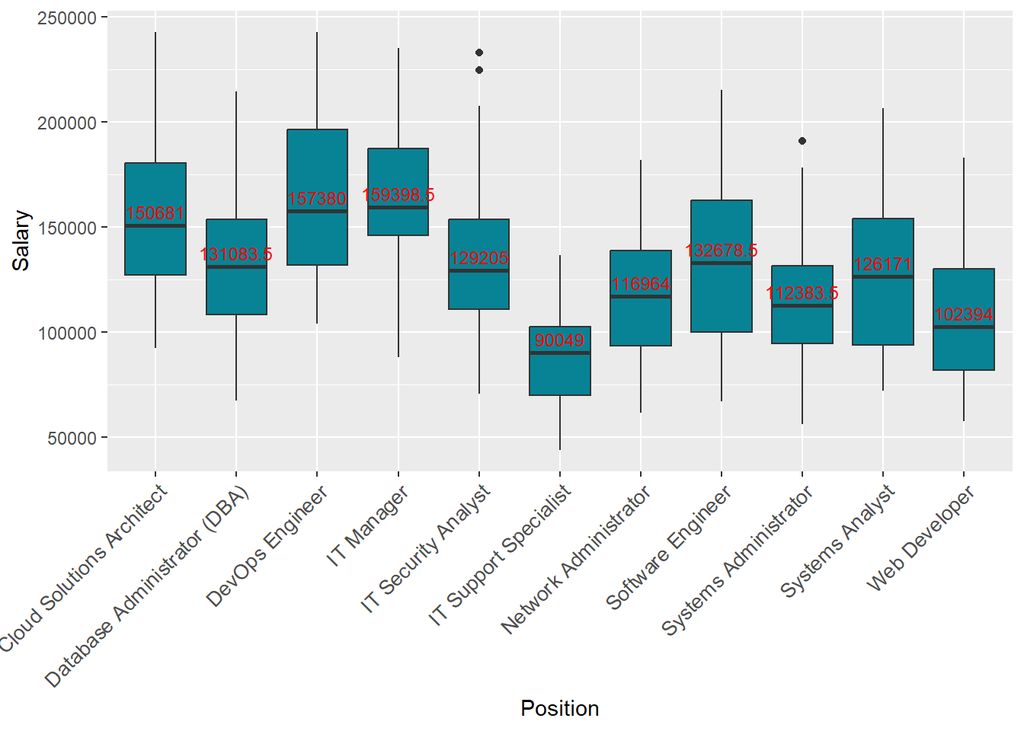

```r
basic = ggplot(data,aes(x=Position,y=Salary))
basic + geom_boxplot(trim=FALSE,adjust=0.5,fill="#088395") + theme(axis.text.x=element_text(angle=45,hjust=1, size=10)) + labs(x="Position",y="Salary") + stat_summary(fun = median, geom = "text", aes(label = round(..y.., 1)), vjust = -0.5, color = "red", size = 3)
```

## 5. If I have 5 years of experience, what will my salary be?

Let’s try to create a simple linear regression model, and see how much my salary would be if I have 5 years of experience, no matter my position.

There are couple of assumptions that we need to check before we do linear regression:

1. Linearity: The relationship between the dependent and independent variables should be linear.
2. Independence: Observations should be independent of each other.
3. Homoscedasticity: The residuals (errors) should have constant variance at every level of the independent variables.
4. Normality: The residuals should be approximately normally distributed.
5. No Multicollinearity (for multiple linear regression): The independent variables should not be too highly correlated with each other.

Let’s check LINEARITY:

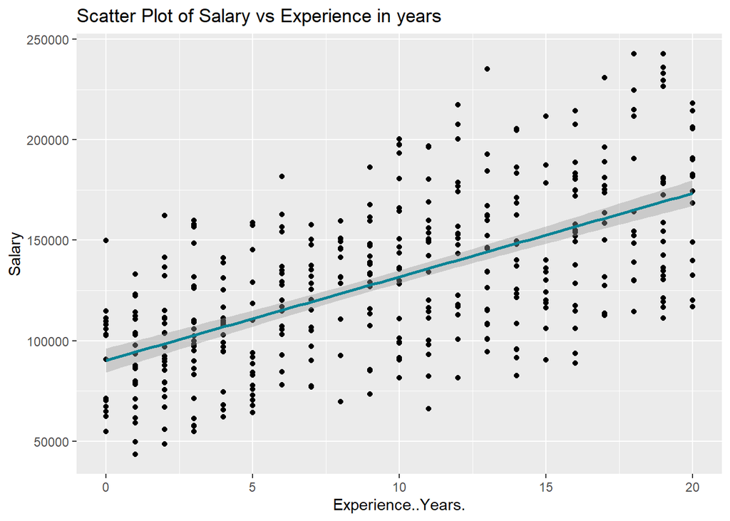

```r
model <- lm(Salary ~ Experience..Years., data = data)
ggplot(data, aes(x = Experience..Years., y = Salary)) + geom_point() +  geom_smooth(method = "lm", col = "#088395") + labs(title = "Scatter Plot of Salary vs Experience in years", x = "Experience..Years.", y = "Salary")
```

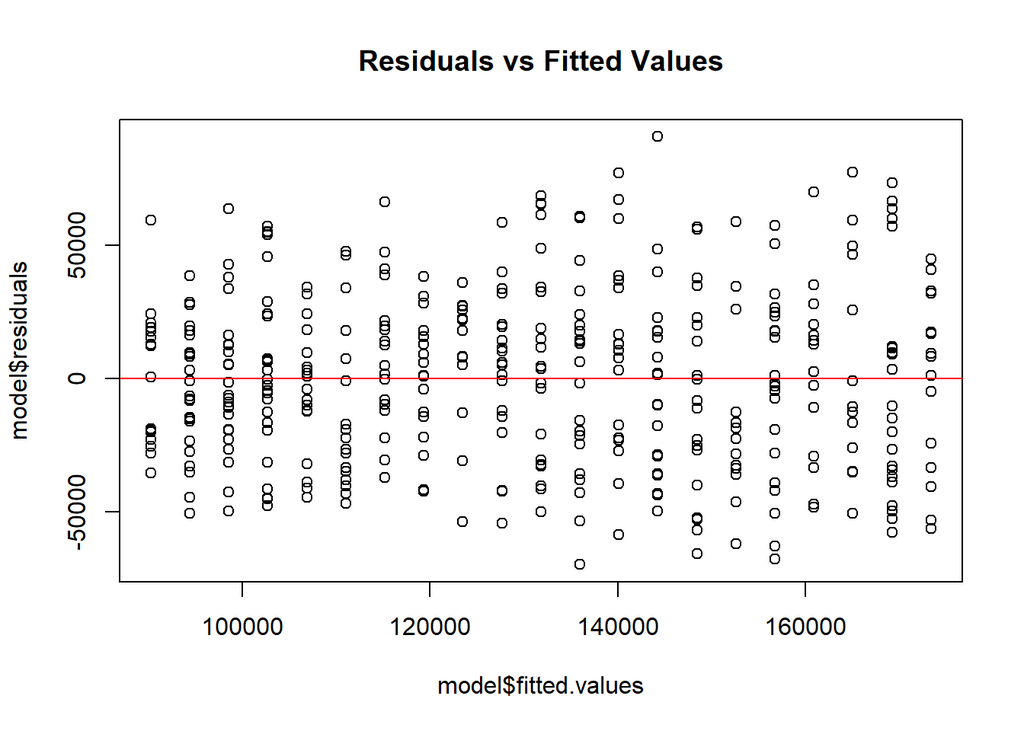

```r
plot(model$fitted.values, model$residuals)
abline(h = 0, col = "red")
title("Residuals vs Fitted Values")
```

Checking HOMOSCEDASTICITY

```r
options(repos = c(CRAN = "https://cran.rstudio.com/"))
install.packages("lmtest")
library(lmtest)
```

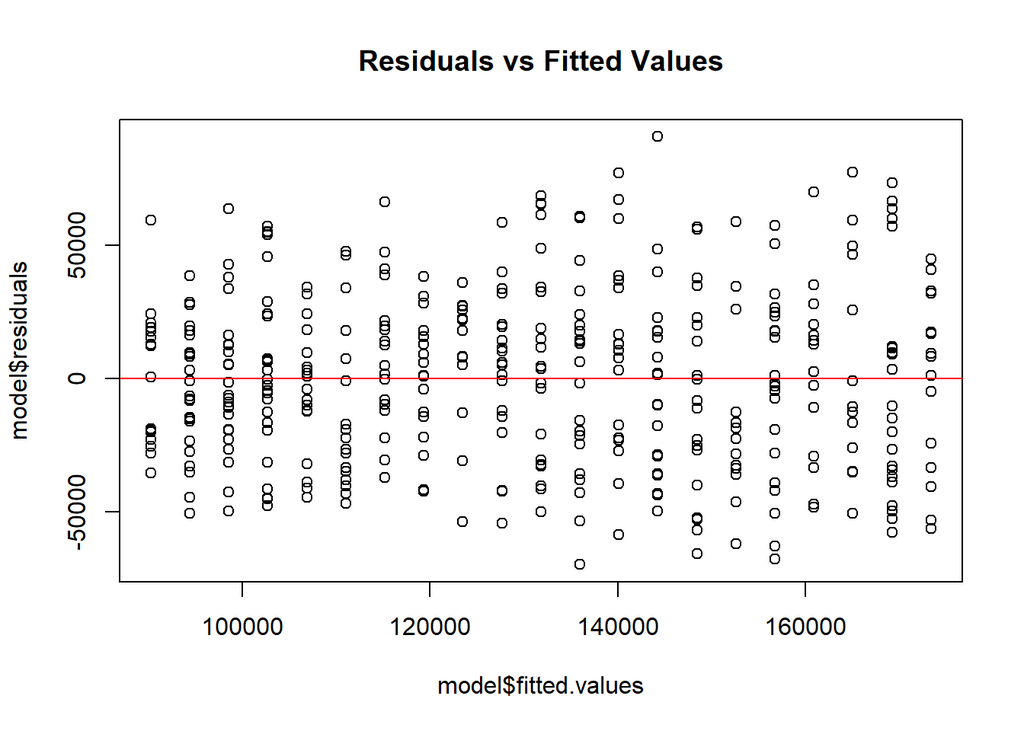

```r
plot(model$fitted.values, model$residuals)
abline(h = 0, col = "red")
title("Residuals vs Fitted Values")
```

```r
bptest(model)
```

```
##
##  studentized Breusch-Pagan test
##
## data:  model
## BP = 17.458, df = 1, p-value = 0.00002938
```

The p-value of Breusch-Pagan test should be higher than 0.05 to show homoscedasticity. Assumption failed.

Checking NORMALITY OF RESIDUALS

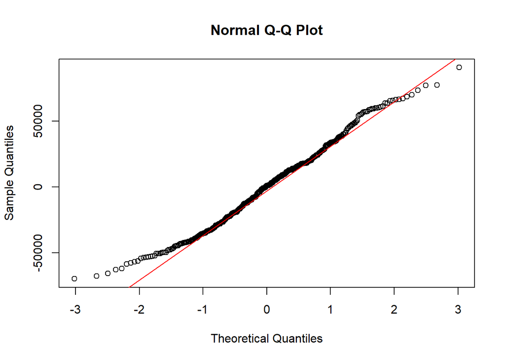

```r
qqnorm(model$residuals)
qqline(model$residuals, col = "red")
```

```r
shapiro.test(model$residuals)
```

```
##
##  Shapiro-Wilk normality test
##
## data:  model$residuals
## W = 0.98714, p-value = 0.001445
```

Values should go along the Q-Q plot, here they majorly are, but not on the tails. P-value should be higher than 0.05. Assumption failed.

```r
summary(model)
```

```
##
## Call:
## lm(formula = Salary ~ Experience..Years., data = data)
##
## Residuals:
##    Min     1Q Median     3Q    Max
## -69913 -25808    810  19949  90932
##
## Coefficients:
##                    Estimate Std. Error t value            Pr(>|t|)
## (Intercept)           90264       3052   29.58 <0.0000000000000002 ***
## Experience..Years.     4157        269   15.45 <0.0000000000000002 ***
## ---
## Signif. codes:  0 '***' 0.001 '**' 0.01 '*' 0.05 '.' 0.1 ' ' 1
##
## Residual standard error: 32490 on 393 degrees of freedom
## Multiple R-squared:  0.3779, Adjusted R-squared:  0.3763
## F-statistic: 238.8 on 1 and 393 DF,  p-value: < 0.00000000000000022
```

The p-values are good, lower than 0.05, but the issue is that the R-squared is quite small, only 37,63% of the variation is explained with this model in this dataset.

If my experience would be 0, I would get salary around 90.264 USD, and if I would have 5 years of experience, I would get 90,264 + 4,157 * 5 = 111.049 USD.

According to this model, with each year of experience, I would get a raise of 4.157 USD.